# Herring ESP potential indicators

Sarah Gaichas

2024-06-28

# 1 Introduction

This document visualizes existing datasets, MOST OF WHICH ARE NOT SPECIFIC TO HERRING.

That said, herring survey strata in the fall look a lot like the combined Gulf of Maine (GOM) and Georges Bank (GB).

Herring strata in the spring look like the full shelf, GOM, GB, and the Mid Atlantic Bight (MAB).

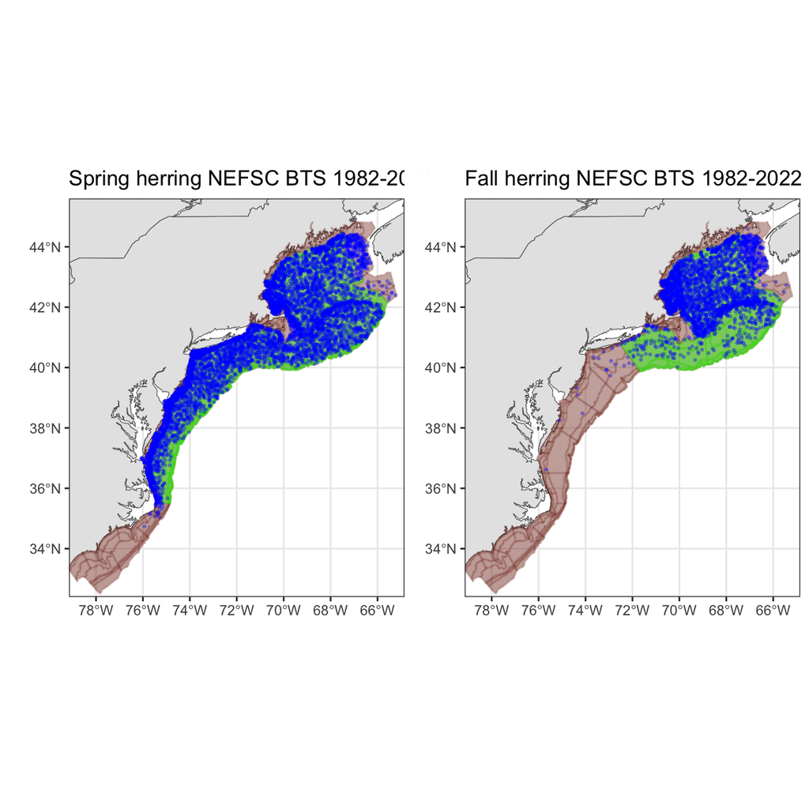

```r
# from Jon
herring_spring <- c(01010, 01020, 01030, 01040, 01050, 01060, 01070, 01080, 01090,
                    01100, 01110, 01120, 01130, 01140, 01150, 01160, 01170, 01180,
                    01190, 01200, 01210, 01220, 01230, 01240, 01250, 01260, 01270,
                    01280, 01290, 01300, 01360, 01370, 01380, 01390, 01400, 01610,
                    01620, 01630, 01640, 01650, 01660, 01670, 01680, 01690, 01700,
                    01710, 01720, 01730, 01740, 01750, 01760)
herring_fall <- c(01050, 01060, 01070, 01080, 01090, 01100, 01110, 01120, 01130,
                  01140, 01150, 01160, 01170, 01180, 01190, 01200, 01210, 01220,
                  01230, 01240, 01250, 01260, 01270, 01280, 01290, 01300, 01360,
                  01370, 01380, 01390, 01400)

herring_springgrid <-  FishStatsUtils::northwest_atlantic_grid %>%
  filter(stratum_number %in% herring_spring)

herring_fallgrid <-  FishStatsUtils::northwest_atlantic_grid %>%
  filter(stratum_number %in% herring_fall)

survdat_herring_tows <- readRDS(here::here("herringpyindex/survdat_herring_tows.rds"))

surv_herr_fall <- survdat_herring_tows |>
  dplyr::filter(SEASON == "FALL",
                YEAR > 1981)

surv_herr_spring <- survdat_herring_tows |>
  dplyr::filter(SEASON == "SPRING",
                YEAR > 1981)

Fall <- ggplot(data = ecodata::coast) +
  geom_sf() +
  geom_point(data = FishStatsUtils::northwest_atlantic_grid, aes(x = Lon, y = Lat),  colour = "coral4", size=0.05, alpha=0.1) +
  geom_point(data = herring_fallgrid, aes(x = Lon, y = Lat),  colour = "green", size=0.05, alpha=0.1) +
  geom_point(data = surv_herr_fall, aes(x = LON, y = LAT), colour = "blue", size=0.5, alpha=.3) +
  coord_sf(xlim =c(-78.5, -65.5), ylim = c(33, 45)) + #zoomed to Hatteras and N
  xlab("") +
  ylab("") +
  ggtitle("Fall herring NEFSC BTS 1982-2022")+
  theme(plot.margin = margin(0, 0, 0, 0, "cm"))

Spring <- ggplot(data = ecodata::coast) +
  geom_sf() +
  geom_point(data = FishStatsUtils::northwest_atlantic_grid, aes(x = Lon, y = Lat),  colour = "coral4", size=0.05, alpha=0.1) +
  geom_point(data = herring_springgrid, aes(x = Lon, y = Lat),  colour = "green", size=0.05, alpha=0.1) +
  geom_point(data = surv_herr_spring, aes(x = LON, y = LAT), colour = "blue", size=0.5, alpha=.3) +
  coord_sf(xlim =c(-78.5, -65.5), ylim = c(33, 45)) + #zoomed to Hatteras and N
  xlab("") +
  ylab("") +
  ggtitle("Spring herring NEFSC BTS 1982-2022")+
  theme(plot.margin = margin(0, 0, 0, 0, "cm"))

Spring + Fall
```

The goal is to identify which are most promising for further refinement.

Refinement can include evaluating different spatial footprints or seasons or both.

# 2 Recruitment indicators in `ecodata` or elsewhere

## 2.1 Upper TL:

### 2.1.1 Egg/larval predators → haddock (Micah’s work)

### 2.1.2 Competitors → gelantinous zooplankton

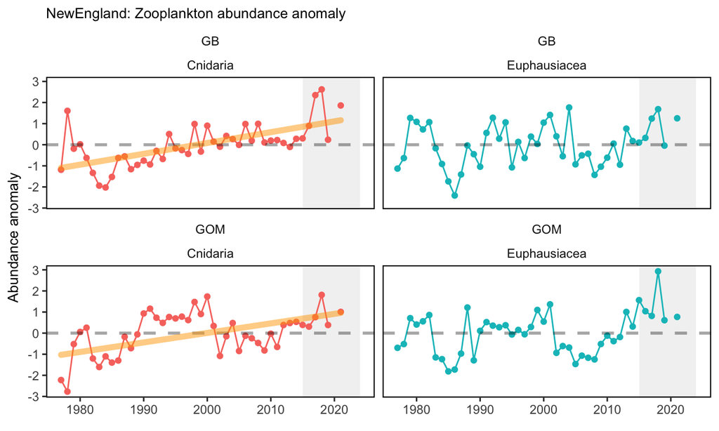

```r
ecodata::plot_zoo_abundance_anom(report = "NewEngland", varName = "euphausid")
```

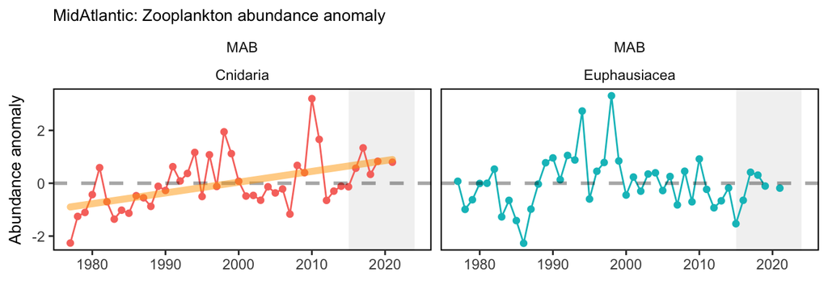

```r
ecodata::plot_zoo_abundance_anom(report = "MidAtlantic", varName = "euphausid")
```

### 2.1.3 Seabirds

Common tern fledgling success at GOM nesting colonies

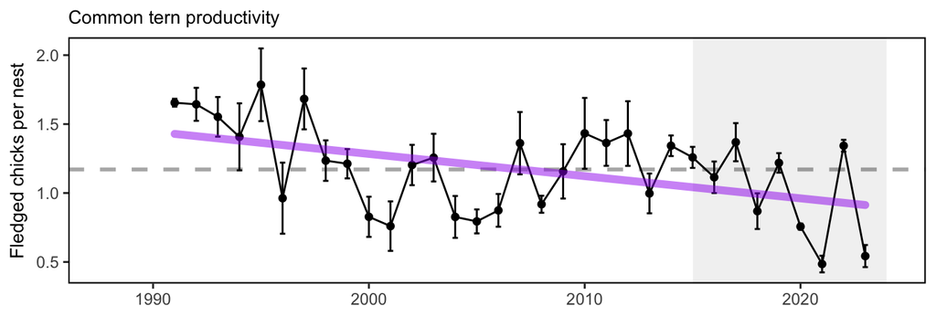

```r
ecodata::plot_seabird_ne(report = "NewEngland", varName = "productivity")
```

## 2.2 Lower TL:

### 2.2.1 Primary production (Chlorophyll)

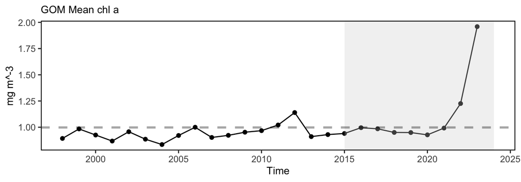

```r
ecodata::plot_annual_chl_pp(report = "NewEngland", EPU = "GOM", varName = "chl", plottype = "mean") + ggplot2::ggtitle("GOM Mean chl a")
```

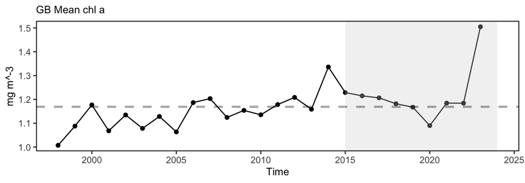

```r
ecodata::plot_annual_chl_pp(report = "NewEngland", EPU = "GB", varName = "chl", plottype = "mean") + ggplot2::ggtitle("GB Mean chl a")
```

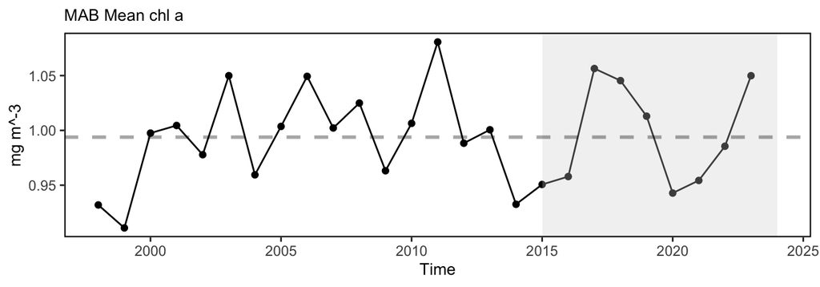

```r
ecodata::plot_annual_chl_pp(report = "MidAtlantic", EPU = "MAB", varName = "chl", plottype = "mean") + ggplot2::ggtitle("MAB Mean chl a")
```

### 2.2.2 Small zooplankton timing and availability

Relative availability from SOE

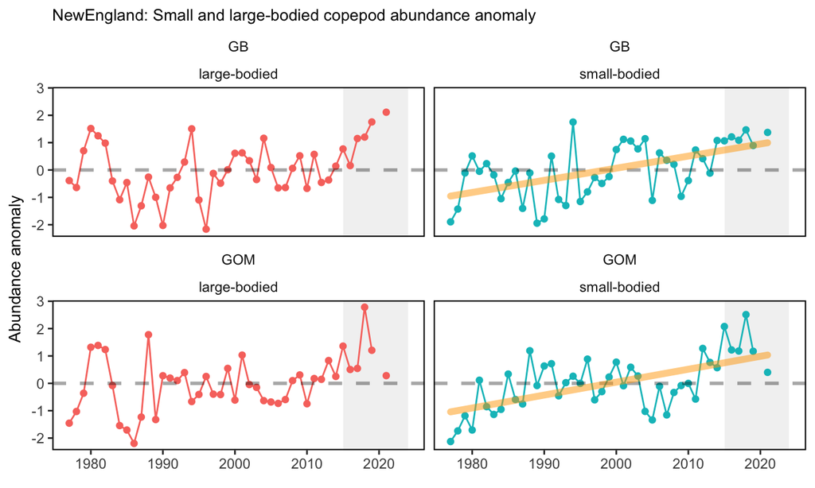

```r
ecodata::plot_zoo_abundance_anom(report = "NewEngland", varName = "copepod")
```

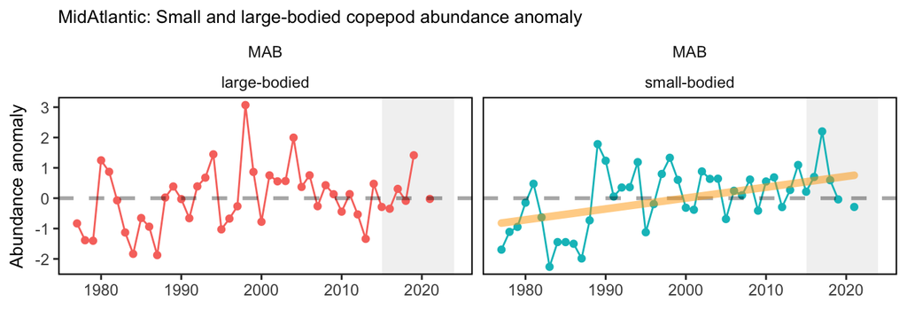

```r
ecodata::plot_zoo_abundance_anom(report = "MidAtlantic", varName = "copepod")
```

### 2.2.3 Large zooplankton timing and availability

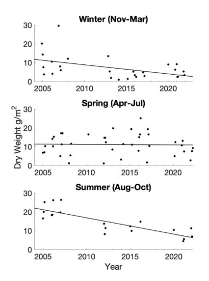

Figure 2.1: Dry mass of mesozooplankton captured with a 200µm ring net towed from the bottom to surface at a deep time series station in Wilkinson Basin between 2005-2022 (Runge et al. 2023).

```r
magick::image_read("https://github.com/NOAA-EDAB/ecodata/blob/dev/workshop/images/WBTS_Mesozooplankton_BIomass_2005-2022_Runge_Dullaert-Jeffrey_Runge_2024.jpg?raw=true")
```

See also [zooplankton page](https://noaa-edab.github.io/forageindex/ZooplanktonOverview.html)

See also [preliminary Cal fin indices](https://noaa-edab.github.io/zooplanktonindex/TestResults.html) annual and by season for herring areas

Small copeopod indices in development

## 2.3 Physical:

### 2.3.1 Temperature (surface and bottom)

Its going up, [bottom temp in all seasons](https://noaa-edab.github.io/catalog/bottom_temp_comp.html)

and [surface temp in all seasons](https://noaa-edab.github.io/catalog/seasonal_oisst_anom.html)

BUT, I think what we want is number of days at or above a threshold by area, like this plot for scallops:

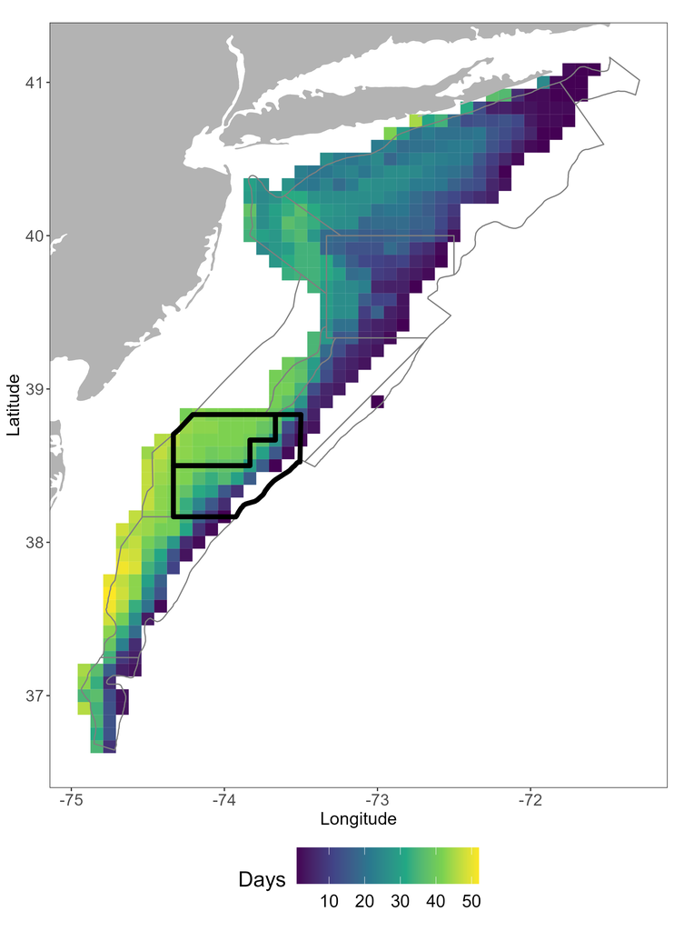

days exceeding scallop stress temperature 2022

For this we need a threshold/stressful temperature for herring eggs (bottom temp), larvae, and recruits (surface temp?)

### 2.3.2 Heatwave index

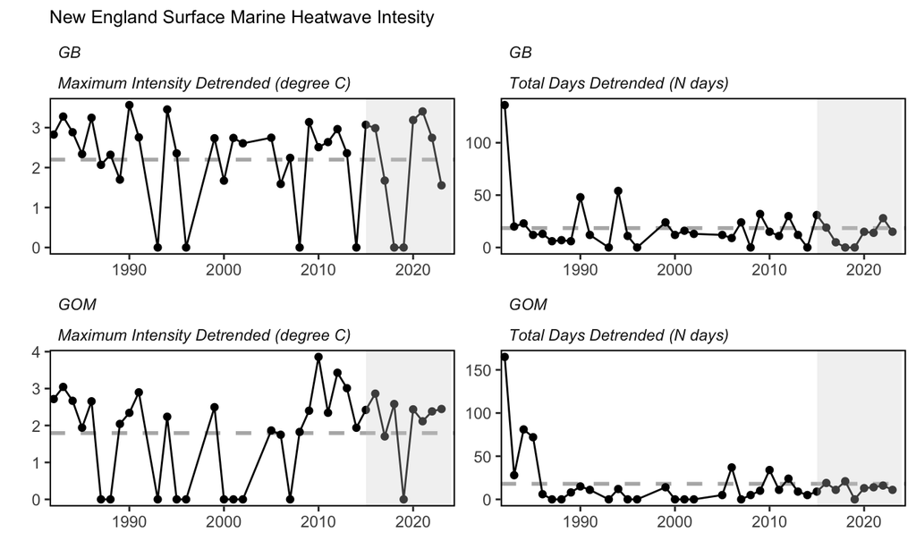

```r
ecodata::plot_heatwave(report = "NewEngland")
```

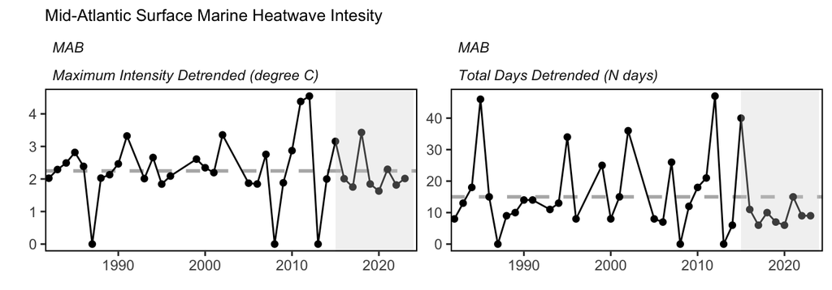

```r
ecodata::plot_heatwave(report = "MidAtlantic")
```

### 2.3.3 Climate variability (ie NAO)

### 2.3.4 Larval transport processes (wind, currents)

## 2.4 Demographic:

### 2.4.1 Fecundity

### 2.4.2 Body condition (deviation from expected weight at length)

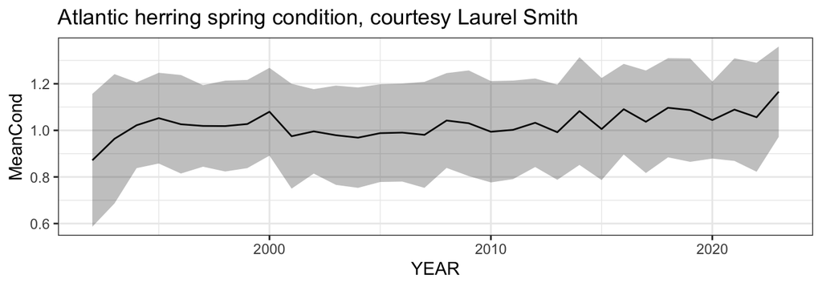

```r
load("/Users/sarah.gaichas/Documents/0_Data/zooplanktonindex/data/AtlHerring_SpringCondition.RData")

ggplot2::ggplot(condNSpp, ggplot2::aes(x = YEAR, y = MeanCond)) +
  ggplot2::geom_line() +
  ggplot2::geom_ribbon(ggplot2::aes(ymin = MeanCond-(2*StdDevCond), ymax = MeanCond+(2*StdDevCond)), alpha = 0.3) +
  ggplot2::ggtitle("Atlantic herring spring condition, courtesy Laurel Smith")
```

### 2.4.3 Regime shift?

# 3 Mortality

## 3.1 Upper:

### 3.1.1 Bluefin tuna

Need indicator of timing/abundance in herring region

### 3.1.2 Marine Mammals

Data on this may be hard to find

### 3.1.3 Demersal fish

See Gartland et al in review, consumption estimates

Overlap index with predators?

## 3.2 Lower:

### 3.2.1 Zooplankton community structure

Increases in diversity due to lower abundance of common species

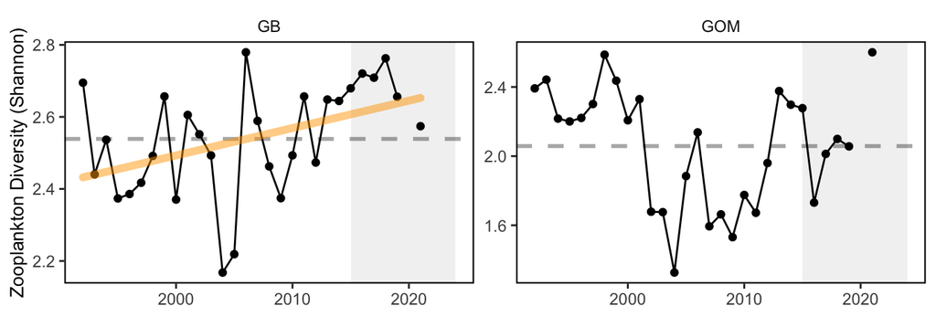

```r
ecodata::plot_zoo_diversity(report = "NewEngland")
```

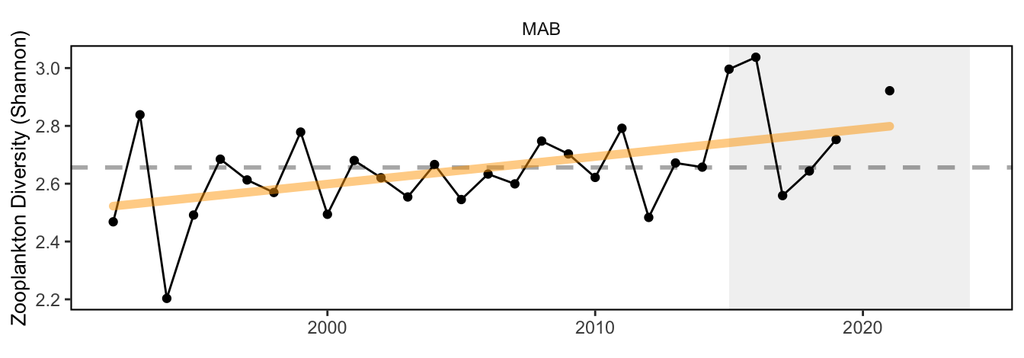

```r
ecodata::plot_zoo_diversity(report = "MidAtlantic")
```

### 3.2.2 Zooplankton abundance, phenology, and energy content

Abundance and phenology see above

### 3.2.3 Menhaden competition/alternative stable states

## 3.3 Physical:

### 3.3.1 Sea surface temperature

(see above)

## 3.4 Demographic

### 3.4.1 Energy density

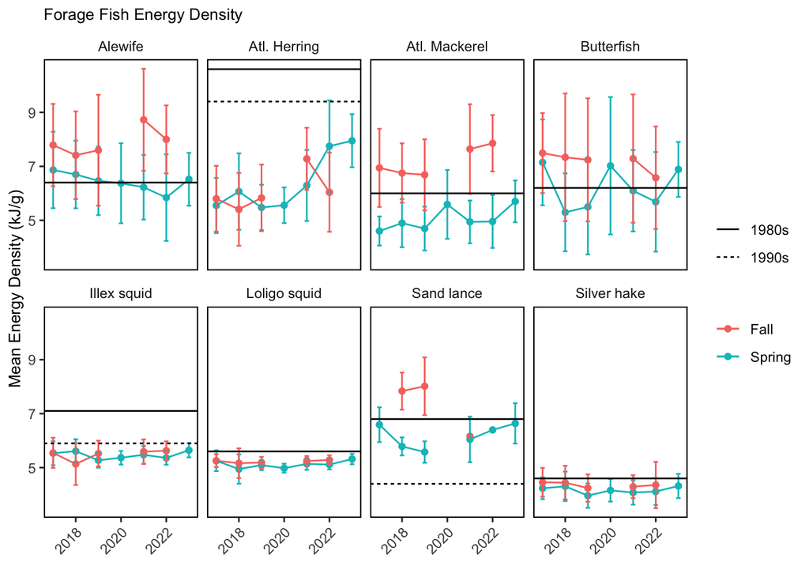

```r
ecodata::plot_energy_density()
```